# Statistical Methods in Data Science 2: Final Project

## 7.2 Normality testing

The distributions of $\beta_2$ and $\beta_3$ seems to be pretty normal (truncated). We can check it by making a [Kolmogorov-Smirnov test](https://en.wikipedia.org/wiki/Kolmogorov%E2%80%93Smirnov_test) that we remeber examines if scores are likely to follow some distribution in some population. There are various kind of this test, we’re interested in the **one sample Kolmogorov-Smirnov** test for testing if a variable follows a given distribution in a population. This “given distribution” is usually -and in our case- the normal distribution, hence “Kolmogorov-Smirnov normality test”.

In a KS test, the null hypothesis is that our sample follows the distribution we compare it against. So higher is the statistic, higher is valid the rejection of the null. In fact, without going too much deep, we can consider the statistics as a measure of the distance (in particular the $\operatorname{sup}$) between the empirical distributions of the sample and the distribution we think it follows.In particular, we decide we need a **Type I** error probability $\le 0.05$ and so our rejection rule is reject high statistic values $H_0$ if

$$p-value \le 0.05$$

```
##
##  One-sample Kolmogorov-Smirnov test
##
## data:  beta2_chain1
## D = 0.52671, p-value < 2.2e-16
## alternative hypothesis: two-sided
```

```
##
##  One-sample Kolmogorov-Smirnov test
##
## data:  beta3_chain1
## D = 0.46535, p-value < 2.2e-16
## alternative hypothesis: two-sided
```

We’re going to compare the standardized sample distribution against a standard Normal.

- $\beta_2$:

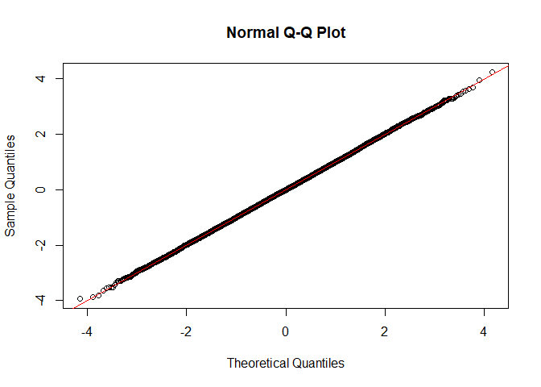

- $\beta_3$:

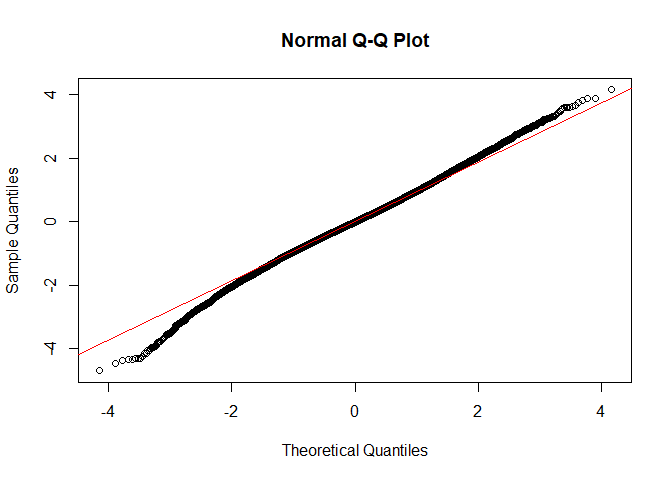

```r
z <- (beta3_chain1-mean(beta3_chain1))/sd(beta3_chain1)
qqnorm(z); qqline(z, col = 2)
```

# 8 Conclusions

With this simple work we explored the power and the weakness of Bayesian Analysis. We at first tried to face a not so easy model, exploting it trough both BUGS and Jags, and comparing it with its “frequentist version” and with a simpler model that come out works better. Of curse many little things could be improved but this is not the place.